# Compte rendu TP1 - Initiation à R

Boufenouche Bouchra groupe BBS

Le 2 Septembre2024

# Premiers pas avec R et RMarkdown

Ceci est un document de type R Markdown. Markdown est une mise en forme syntaxique simplifiée pour rédiger des documents HTML, PDF ou encore MsWord. Pour plus de détails sur l’utilisation de R Markdown cf. http://rmarkdown.rstudio.com.

Il existe beaucoup de documents et tutoriels en ligne que vous pouvez explorer par vous-même. Exemples :

- Mise en forme du texte : https://rmarkdown.rstudio.com/lesson-8.html
- Bouts de code R (chunks) : https://rmarkdown.rstudio.com/lesson-3.html

# Utilisation et calcul avec du code R

Cette partie est à compléter avec le sujet de TP en ligne : http://silico.biotoul.fr/site/index.php/M1_Traitement_de_Donnees_Biologiques_-_TP_Intro_R

## Utilisation de variables

Les variables (ou objets) permettent de stocker des données qui peuvent être :

- une valeur simple de type numérique (`numeric`), logique (`logical`), chaîne de caractères (`character`) ou qualitative (`factor`).
- une liste (appelée `vector`).
- un tableau à 2 dimensions, les colonnes pouvant avoir des types différents (`data.frame`). Ce sont les plus utilisés en statistiques.
- un tableau à 2 dimensions, toutes les cases ayant le même type (`matrix`).
- un tableau à plus de 2 dimension (`array`).
- une combinaison des précédents (`list`).

Une variable a un nom (défini par l’utilisateur) qui permet d’accéder à son contenu.

**Créer une variable appelée x qui stocke le résultat du calcul précédent 1 + 2 + 3.** L’affectation d’une valeur à une variable se fait avec <- ou le signe = comme suit dans la console :

```r
x = 1 + 2 + 3 ;x #le ";x" permet d'afficher le contenu de la variable x
```

```
## [1] 6
```

```r
#Autres types de variables simples:
texte = "Phrase qu'il faut mettre entre guillemets."
logique = TRUE
faux = FALSE

x = x * 2 # on multiplie x de toute à l'heure par 2
y = x**2  # y prend la valeur de x au carré (puissance 2)

#Les valeurs logiques peuvent être le résultats de tests :
x < 10  # strictement inférieur à 10 ?
```

```
## [1] FALSE
```

```r
x <= 11 # inférieur ou égal
```

```
## [1] FALSE
```

```r
x == 12 # test d'égalité
```

```
## [1] TRUE
```

```r
x >= 13
```

```
## [1] FALSE
```

```r
x > 0
```

```
## [1] TRUE
```

```r
x != 0 # test si x est différent de 0
```

```
## [1] TRUE
```

## Vecteurs

```r
x = c(2,3,5,8,4,6);x #Création d'un vecteur x
```

```
## [1] 2 3 5 8 4 6
```

```r
length(x) #la fonction length() permet de calculer la longueur du vecteur x
```

```
## [1] 6
```

```r
x[2] #Pour aficherla deuxième valeur de x , les crochets pour accéder à certains éléments
```

```
## [1] 3
```

```r
x[ c(2,4,1) ]#Pour accéder à plusieurs éléments, on utilise un vecteur contenant les positions
```

```
## [1] 3 8 2
```

```r
x[2:4] #Si les positions se suivent , donc avec cette ligne de commande on va afficher les éléments de la position 2 ,3 et 4
```

```
## [1] 3 5 8
```

```r
x[4:2] #ou dans l'ordre inverse
```

```
## [1] 8 5 3
```

```r
x[ -2 ] # tous, sauf le 2ème
```

```
## [1] 2 5 8 4 6
```

```r
x[ -2:-3 ] # tous, sauf le 2ème et le 3ème
```

```
## [1] 2 8 4 6
```

```r
# on peut également utiliser la fonction setdiff() pour exclure un ou plusieurs éléments ou avec Which par exemple x[-which(x==3)] (3 est l'index de l'élément à exclure)
x>4 # teste chaque élément de X s'il est sup ou inf à 4
```

```
## [1] FALSE FALSE  TRUE  TRUE FALSE  TRUE
```

```r
which( x>4 ) # récuperer les éléments dont les index sont sup à 4
```

```
## [1] 3 4 6
```

```r
x[ x>4 ] # les valeurs qui sont supérieur à 4
```

```
## [1] 5 8 6
```

```r
x
```

```
## [1] 2 3 5 8 4 6
```

```r
1 / x # l'inverse de tous les éléments de X
```

```
## [1] 0.5000000 0.3333333 0.2000000 0.1250000 0.2500000 0.1666667
```

```r
# en arrondissant 2 chiffres après la virgule)
round(1/x, 2)
```

```
## [1] 0.50 0.33 0.20 0.12 0.25 0.17
```

```r
x + 1 # élément par élément
```

```
## [1] 3 4 6 9 5 7
```

```r
x * 2 #élément par élément
```

```
## [1]  4  6 10 16  8 12
```

## Fonctions

```r
    summary(x) #Cette fonction fournit un résumé statistique: La valeur minimale | Le premier quartile (25%)  | La médiane (50%) | La moyenne | Le troisième quartile (75%)  | La valeur maximale
```

```
##    Min. 1st Qu.  Median    Mean 3rd Qu.    Max.
##   2.000   3.250   4.500   4.667   5.750   8.000
```

```r
    min(x) #Cette fonction renvoie la valeur minimale.
```

```
## [1] 2
```

```r
    max(x) #Cette fonction renvoie la valeur maximale
```

```
## [1] 8
```

```r
    median(x) #Cette fonction renvoie la médiane, d'un vecteur ou liste ou autre structures de données sur R , qui est la valeur qui sépare le vecteur en deux parties égales.
```

```
## [1] 4.5
```

```r
    mean(x) #Cette fonction calcule la moyenne (moyenne arithmétique) des éléments d'une structure de données.
```

```
## [1] 4.666667
```

```r
    var(x) #Cette fonction calcule la variance ,qui mesure la dispersion des valeurs.
```

```
## [1] 4.666667
```

```r
    sd(x) #Cette fonction calcule l'écart-type, qui est la racine carrée de la variance et donne une idée de la dispersion des valeurs par rapport à la moyenne.
```

```
## [1] 2.160247
```

```r
 help(median)
```

```
## démarrage du serveur d'aide httpd ... fini
```

```r
 #La fonction help() en R est utilisée pour accéder à la documentation des fonctions, des objets et des packages.
 # on peut utiliser également ?mean ou Quand on ne connaît pas exactement le nom, on peut faire une recherche par mot :??mean
```

## Lecture et écriture de fichiers contenant des données

```r
read.table("Croissance_plantes.txt",sep="\t",header=TRUE)
```

```
##     poids taille origine_geo
## 1   383.5   44.4         pyr
## 2   395.8   50.7         pyr
## 3   406.8   53.5         pyr
## 4   387.7   54.1         pyr
## 5   407.6   54.3         pyr
## 6   387.6   54.9         pyr
## 7   393.3   54.9         pyr
## 8   402.4   55.1         pyr
## 9   392.9   55.4         pyr
## 10  396.5   55.4         pyr
## 11  383.2   55.8         pyr
## 12  407.7   55.8         pyr
## 13  402.6   56.0         pyr
## 14  422.1   56.6         pyr
```

[output cut: 86 more lines]

```r
croissance = read.table("Croissance_plantes.txt", sep="\t", header=TRUE, stringsAsFactors=T) #data frame
summary(croissance)
```

```
##      poids           taille        origine_geo
##  Min.   :383.2   Min.   :44.40   pyr     :16
##  1st Qu.:406.3   1st Qu.:60.90   espagne :15
##  Median :420.8   Median :66.50   toulouse:10
##  Mean   :419.5   Mean   :66.97   alpes   : 9
##  3rd Qu.:432.1   3rd Qu.:73.15   lorient : 8
##  Max.   :459.1   Max.   :88.50   rouen   : 8
##                                  (Other) :34
```

```r
dim(croissance) #La fonction dim() etourne les dimensions du data frame
```

```
## [1] 100   3
```

```r
croissance
```

```
##     poids taille origine_geo
## 1   383.5   44.4         pyr
## 2   395.8   50.7         pyr
## 3   406.8   53.5         pyr
## 4   387.7   54.1         pyr
## 5   407.6   54.3         pyr
## 6   387.6   54.9         pyr
## 7   393.3   54.9         pyr
## 8   402.4   55.1         pyr
## 9   392.9   55.4         pyr
## 10  396.5   55.4         pyr
## 11  383.2   55.8         pyr
## 12  407.7   55.8         pyr
## 13  402.6   56.0         pyr
## 14  422.1   56.6         pyr
```

[output cut: 86 more lines]

```r
croissance[1 ,  ] # ligne 1
```

```
##   poids taille origine_geo
## 1 383.5   44.4         pyr
```

```r
croissance[  , 1] # colonne 1
```

```
##   [1] 383.5 395.8 406.8 387.7 407.6 387.6 393.3 402.4 392.9 396.5 383.2 407.7
##  [13] 402.6 422.1 402.9 403.1 390.2 417.3 396.9 398.4 403.3 410.4 389.6 398.3
##  [25] 389.6 400.3 402.9 417.5 392.8 415.4 412.7 420.8 412.0 403.1 421.8 423.2
##  [37] 421.8 418.5 436.8 420.7 414.2 415.5 436.1 412.5 423.3 431.9 431.6 403.4
##  [49] 421.1 420.2 413.6 433.5 413.5 404.8 431.0 422.3 424.1 418.4 437.7 442.0
##  [61] 422.1 421.3 410.2 433.8 431.5 426.2 429.9 427.8 425.6 430.0 415.4 427.1
##  [73] 422.5 422.5 416.1 429.1 437.4 453.7 434.8 437.1 441.5 416.4 432.5 440.7
##  [85] 424.3 435.1 440.8 446.9 420.7 415.6 446.5 436.6 443.8 415.4 446.9 442.7
##  [97] 449.6 457.3 459.1 443.7
```

```r
croissance[1, 1] # première case
```

```
## [1] 383.5
```

```r
croissance$poids # colonne qui s'appelle poids (la première)
```

```
##   [1] 383.5 395.8 406.8 387.7 407.6 387.6 393.3 402.4 392.9 396.5 383.2 407.7
##  [13] 402.6 422.1 402.9 403.1 390.2 417.3 396.9 398.4 403.3 410.4 389.6 398.3
##  [25] 389.6 400.3 402.9 417.5 392.8 415.4 412.7 420.8 412.0 403.1 421.8 423.2
##  [37] 421.8 418.5 436.8 420.7 414.2 415.5 436.1 412.5 423.3 431.9 431.6 403.4
##  [49] 421.1 420.2 413.6 433.5 413.5 404.8 431.0 422.3 424.1 418.4 437.7 442.0
##  [61] 422.1 421.3 410.2 433.8 431.5 426.2 429.9 427.8 425.6 430.0 415.4 427.1
##  [73] 422.5 422.5 416.1 429.1 437.4 453.7 434.8 437.1 441.5 416.4 432.5 440.7
##  [85] 424.3 435.1 440.8 446.9 420.7 415.6 446.5 436.6 443.8 415.4 446.9 442.7
##  [97] 449.6 457.3 459.1 443.7
```

```r
croissance[ , 'poids'] # encore une autre manière d'y accéder ou croissance[["poids"]]
```

```
##   [1] 383.5 395.8 406.8 387.7 407.6 387.6 393.3 402.4 392.9 396.5 383.2 407.7
##  [13] 402.6 422.1 402.9 403.1 390.2 417.3 396.9 398.4 403.3 410.4 389.6 398.3
##  [25] 389.6 400.3 402.9 417.5 392.8 415.4 412.7 420.8 412.0 403.1 421.8 423.2
##  [37] 421.8 418.5 436.8 420.7 414.2 415.5 436.1 412.5 423.3 431.9 431.6 403.4
##  [49] 421.1 420.2 413.6 433.5 413.5 404.8 431.0 422.3 424.1 418.4 437.7 442.0
##  [61] 422.1 421.3 410.2 433.8 431.5 426.2 429.9 427.8 425.6 430.0 415.4 427.1
##  [73] 422.5 422.5 416.1 429.1 437.4 453.7 434.8 437.1 441.5 416.4 432.5 440.7
##  [85] 424.3 435.1 440.8 446.9 420.7 415.6 446.5 436.6 443.8 415.4 446.9 442.7
##  [97] 449.6 457.3 459.1 443.7
```

```r
names(croissance) # Pour obtenir le nom des colonnes
```

```
## [1] "poids"       "taille"      "origine_geo"
```

```r
colnames(croissance)
```

```
## [1] "poids"       "taille"      "origine_geo"
```

```r
rownames(croissance)# dans le cas ou les lignes ont des noms ou identifiants
```

```
##   [1] "1"   "2"   "3"   "4"   "5"   "6"   "7"   "8"   "9"   "10"  "11"  "12"
##  [13] "13"  "14"  "15"  "16"  "17"  "18"  "19"  "20"  "21"  "22"  "23"  "24"
##  [25] "25"  "26"  "27"  "28"  "29"  "30"  "31"  "32"  "33"  "34"  "35"  "36"
##  [37] "37"  "38"  "39"  "40"  "41"  "42"  "43"  "44"  "45"  "46"  "47"  "48"
##  [49] "49"  "50"  "51"  "52"  "53"  "54"  "55"  "56"  "57"  "58"  "59"  "60"
##  [61] "61"  "62"  "63"  "64"  "65"  "66"  "67"  "68"  "69"  "70"  "71"  "72"
##  [73] "73"  "74"  "75"  "76"  "77"  "78"  "79"  "80"  "81"  "82"  "83"  "84"
##  [85] "85"  "86"  "87"  "88"  "89"  "90"  "91"  "92"  "93"  "94"  "95"  "96"
##  [97] "97"  "98"  "99"  "100"
```

```r
attach(croissance)
poids
```

```
##   [1] 383.5 395.8 406.8 387.7 407.6 387.6 393.3 402.4 392.9 396.5 383.2 407.7
##  [13] 402.6 422.1 402.9 403.1 390.2 417.3 396.9 398.4 403.3 410.4 389.6 398.3
##  [25] 389.6 400.3 402.9 417.5 392.8 415.4 412.7 420.8 412.0 403.1 421.8 423.2
##  [37] 421.8 418.5 436.8 420.7 414.2 415.5 436.1 412.5 423.3 431.9 431.6 403.4
##  [49] 421.1 420.2 413.6 433.5 413.5 404.8 431.0 422.3 424.1 418.4 437.7 442.0
##  [61] 422.1 421.3 410.2 433.8 431.5 426.2 429.9 427.8 425.6 430.0 415.4 427.1
##  [73] 422.5 422.5 416.1 429.1 437.4 453.7 434.8 437.1 441.5 416.4 432.5 440.7
##  [85] 424.3 435.1 440.8 446.9 420.7 415.6 446.5 436.6 443.8 415.4 446.9 442.7
##  [97] 449.6 457.3 459.1 443.7
```

```r
origine_geo == 'pyr'    # test pour obtenir VRAI/FAUX
```

```
##   [1]  TRUE  TRUE  TRUE  TRUE  TRUE  TRUE  TRUE  TRUE  TRUE  TRUE  TRUE  TRUE
##  [13]  TRUE  TRUE  TRUE  TRUE FALSE FALSE FALSE FALSE FALSE FALSE FALSE FALSE
##  [25] FALSE FALSE FALSE FALSE FALSE FALSE FALSE FALSE FALSE FALSE FALSE FALSE
##  [37] FALSE FALSE FALSE FALSE FALSE FALSE FALSE FALSE FALSE FALSE FALSE FALSE
##  [49] FALSE FALSE FALSE FALSE FALSE FALSE FALSE FALSE FALSE FALSE FALSE FALSE
##  [61] FALSE FALSE FALSE FALSE FALSE FALSE FALSE FALSE FALSE FALSE FALSE FALSE
##  [73] FALSE FALSE FALSE FALSE FALSE FALSE FALSE FALSE FALSE FALSE FALSE FALSE
##  [85] FALSE FALSE FALSE FALSE FALSE FALSE FALSE FALSE FALSE FALSE FALSE FALSE
##  [97] FALSE FALSE FALSE FALSE
```

```r
which(origine_geo == 'pyr') # test pour obtenir les numéros des lignes
```

```
##  [1]  1  2  3  4  5  6  7  8  9 10 11 12 13 14 15 16
```

```r
# et ensuite
croissance[ origine_geo == 'pyr' , 1:2 ] #origine_geo : catégories ,la 3eme colonne n'est plus une variable dans ce cas la donc elle sert à rien
```

```
##    poids taille
## 1  383.5   44.4
## 2  395.8   50.7
## 3  406.8   53.5
## 4  387.7   54.1
## 5  407.6   54.3
## 6  387.6   54.9
## 7  393.3   54.9
## 8  402.4   55.1
## 9  392.9   55.4
## 10 396.5   55.4
## 11 383.2   55.8
## 12 407.7   55.8
## 13 402.6   56.0
## 14 422.1   56.6
## 15 402.9   57.5
## 16 403.1   58.5
```

```r
# ou bien
croissance[ which(origine_geo == 'pyr') , 1:2 ]
```

```
##    poids taille
## 1  383.5   44.4
## 2  395.8   50.7
## 3  406.8   53.5
## 4  387.7   54.1
## 5  407.6   54.3
## 6  387.6   54.9
## 7  393.3   54.9
## 8  402.4   55.1
## 9  392.9   55.4
## 10 396.5   55.4
## 11 383.2   55.8
## 12 407.7   55.8
## 13 402.6   56.0
## 14 422.1   56.6
## 15 402.9   57.5
## 16 403.1   58.5
```

```r
# pour stocker le résultats dans une autre variable
pyr = croissance[ origine_geo == 'pyr' , 1:2 ] #création d'un nouveau data frame
write.table(pyr, "croissance_plantes_pyr.txt", quote=F, col.names=T, row.names=F, sep="\t")
```

## Fonctions graphiques

```r
origine_geo = as.factor(origine_geo)
summary(origine_geo)     # les effectifs
```

```
##    alpes  amsterd brighton  espagne  hamburg  limoges  lorient   nantes
##        9        7        4       15        5        5        8        6
##  norwich      pyr    rouen toulouse
##        7       16        8       10
```

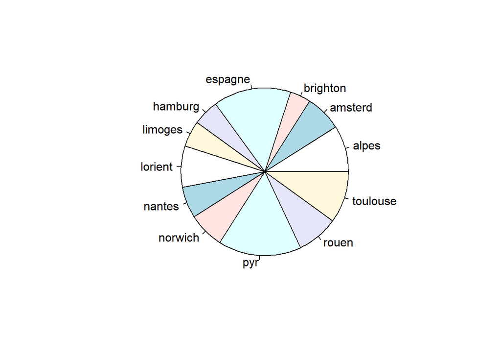

```r
pie(summary(origine_geo))   # le camembert
```

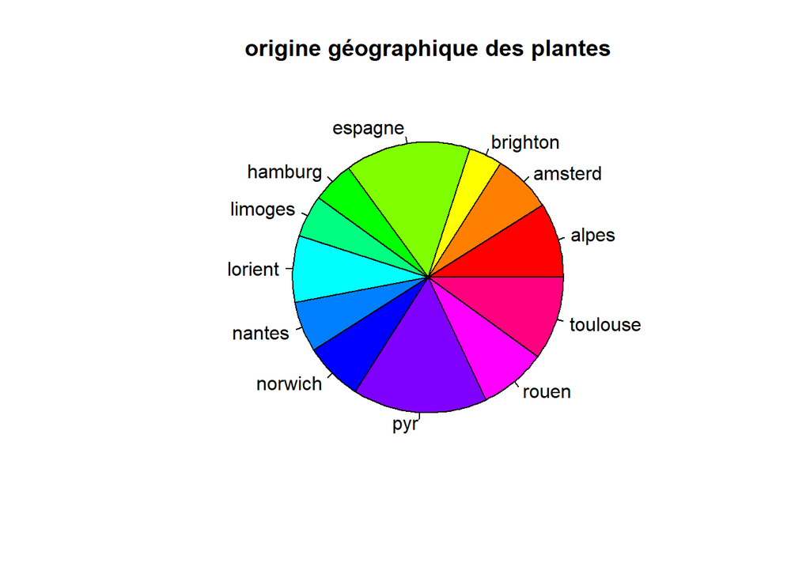

```r
pie (summary(origine_geo), main="origine géographique des plantes",col=rainbow(12)) # avec un titre
```

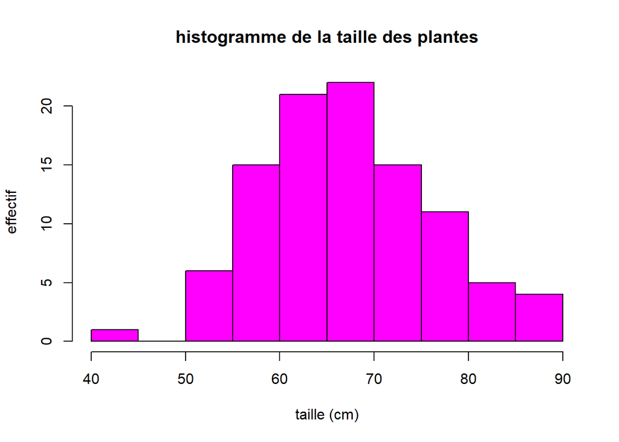

```r
#spectre de couleur : rainbow

#Un histogramme (variable quantitative):
hist(taille, xlim=c(40,90), xlab="taille (cm)", ylab="effectif", freq=T, main="histogramme de la taille des plantes", col="Magenta")
```

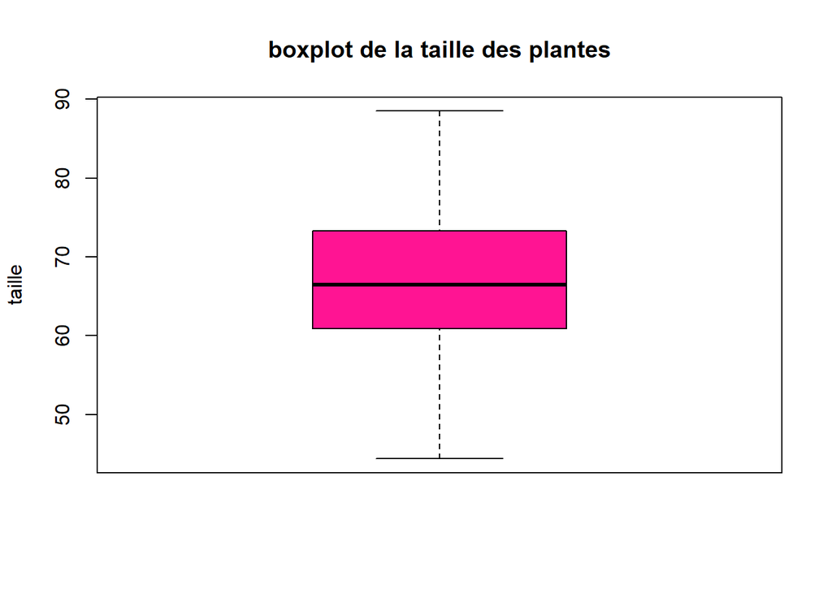

```r
# xlim=c(40,90) : pour visualiser les variables entre 40 et 90
#Une boite à moustaches (variable quantitative):
boxplot(taille, main="boxplot de la taille des plantes", ylab="taille",col="Deep Pink") # la taille moyenne des plantes est entre 65 et 70 selon le boxplot
```

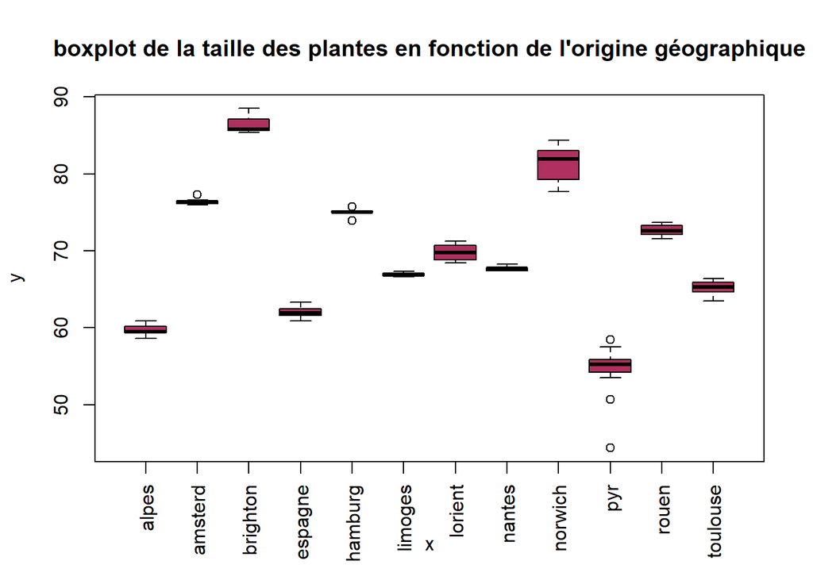

```r
#Plusieurs boites à moustaches (une variable quantitative en fonction des modalités d'une variable qualitative):
plot(origine_geo, taille, las=3, main="boxplot de la taille des plantes en fonction de l'origine géographique",col="Maroon")#L'analyse des boîtes à moustaches montre une hétérogénéité significative dans les tailles des plantes selon leurs origines.
```

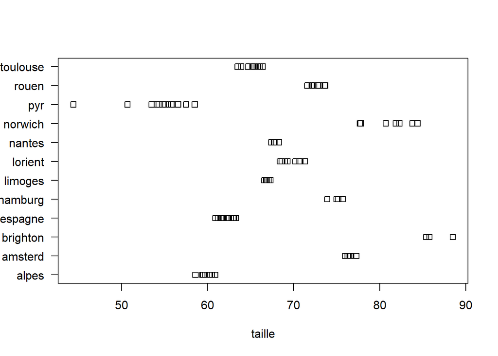

```r
stripchart(taille~origine_geo,las=1) # chaque carré représente un individu .
```

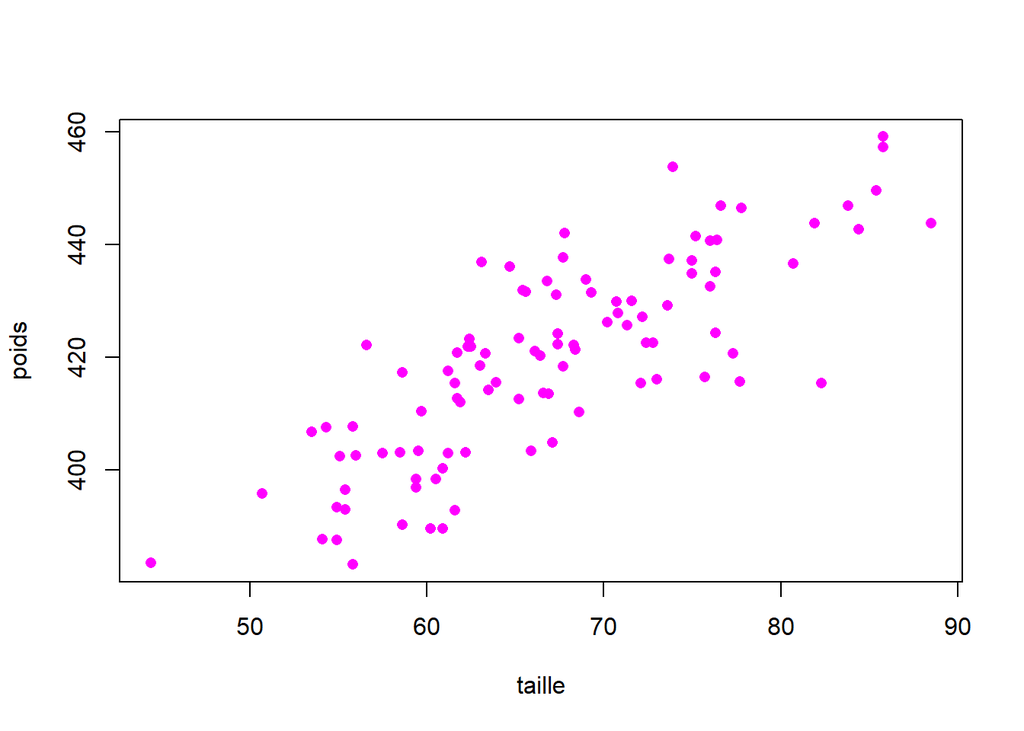

```r
#Un graphique à 2 dimensions ou nuage de points ( 2 variables quantitatives mesurées sur les mêmes individus) :
plot( taille, poids,col="Magenta",pch=16) # Nous observons une corrélation positive entre le poids et la taille des plantes. Cela signifie que, généralement,quand la taille des plantes augmente, leur poids tend également à augmenter.
```

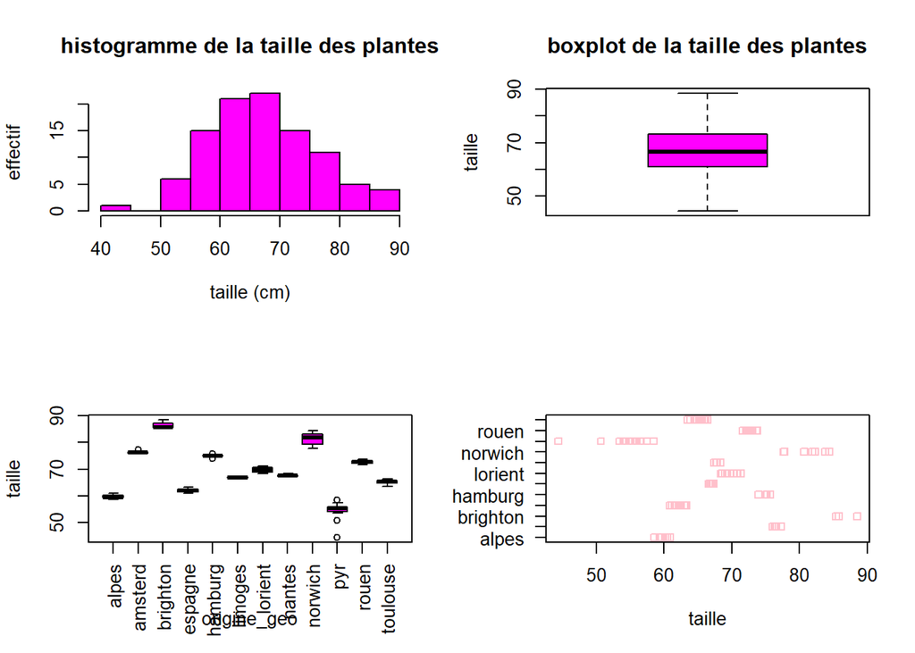

```r
#Affichage de plusieurs graphiques dans la même fenêtre :
par(mfrow=c(2,2))  # 2 en lignes et 2 en colonnes
hist(taille,xlim=c(40,90),xlab="taille (cm)",ylab="effectif",freq=T,main="histogramme de la taille des plantes",col="Magenta")
boxplot(taille,main="boxplot de la taille des plantes",ylab="taille",col="Magenta")
plot(taille~origine_geo,las=3,col ="Magenta")
stripchart(taille~origine_geo,las=1,col="pink")
```

```r
# Conclusion :Ces présentations graphiques montrent  une relation positive entre le poids et la taille des plantes, tout en mettant en évidence une variabilité considérable selon les origines.
#x11(): pour affficher plusieurs graphiques
```